# Dimensionality Reduction of Workplace Attitudes Using PCA

A Principal Component Analysis of the 2024 Pew American Trends Panel

Analysis Report

2026-04-26

# 1 Introduction

This report applies **Principal Component Analysis (PCA)** to the 2024 Pew Research Center American Trends Panel (Wave 157), a nationally representative survey of 5,395 U.S. adults who work full- or part-time for pay, conducted October 7-13, 2024.

The survey contains many overlapping questions about job satisfaction, workplace attitudes, and AI perceptions. PCA is used here to:

1. **Reduce dimensionality**: summarise many correlated survey items into a smaller number of interpretable components
2. **Identify latent structure**: discover underlying dimensions of workplace experience that are not directly observed
3. **Validate predictor selection**: understand which variables carry the most independent information

**Variables selected for PCA:** The nine skill importance items (`SKILLIMP_a` through `SKILLIMP_i`), which ask respondents how important each skill type is for workers to succeed in today’s economy. These nine ordinal Likert items are on the same scale (1=Extremely important to 5=Not at all important), making them ideal candidates for PCA.

> **Note on survey weights:** This analysis does not apply survey weights. Pew provides a weight variable (`WEIGHT_W157`) for analyses intended to generalise to the U.S. working population. All results should be interpreted as descriptive patterns in the sample rather than nationally representative estimates.

# 2 Setup

```r
library(tidyverse)
library(tidymodels)
library(broom)
library(ggrepel)
library(gridExtra)
library(knitr)
```

```r
atp <- read.csv("ATP_W157.csv")

cat("Rows:", nrow(atp), "\n")
```

```
## Rows: 5395
```

```r
cat("Columns:", ncol(atp), "\n")
```

```
## Columns: 152
```

# 3 Data Preparation

## 3.1 Selecting and Cleaning the Skill Importance Variables

The nine `SKILLIMP` items ask: *“How important do you think each of the following is for a worker to be successful in today’s economy?”* Responses are on a 1-5 scale (1 = Extremely important, 5 = Not at all important).

| Variable | Skill Description |
| --- | --- |
| `SKILLIMP_a` | Interpersonal skills (getting along, resolving conflicts) |
| `SKILLIMP_b` | Written and spoken communication skills |
| `SKILLIMP_c` | Management or leadership skills |
| `SKILLIMP_d` | Skills to operate, build, or repair machinery/equipment |
| `SKILLIMP_e` | Physical or manual work / hand tools |
| `SKILLIMP_f` | Basic computer skills (word processing, spreadsheets) |
| `SKILLIMP_g` | High-level math, analytical, or computer skills |
| `SKILLIMP_h` | Skills to understand and use AI tools or technology |
| `SKILLIMP_i` | Critical thinking skills (evaluating facts, informed decisions) |

```r
skill_vars <- c(
  "SKILLIMP_a_W157", "SKILLIMP_b_W157", "SKILLIMP_c_W157",
  "SKILLIMP_d_W157", "SKILLIMP_e_W157", "SKILLIMP_f_W157",
  "SKILLIMP_g_W157", "SKILLIMP_h_W157", "SKILLIMP_i_W157"
)

skill_labels <- c(
  "Interpersonal", "Communication", "Leadership",
  "Machinery/Equipment", "Physical/Manual", "Basic Computer",
  "High-Level Tech", "AI Skills", "Critical Thinking"
)

# Select, rename, and remove missing/refused (coded 98, 99)
skills_clean <- atp %>%
  dplyr::select(all_of(skill_vars)) %>%
  setNames(skill_labels) %>%
  dplyr::filter(if_all(everything(), ~ !. %in% c(98, 99))) %>%
  drop_na()

cat("Complete cases for PCA:", nrow(skills_clean), "\n")
```

```
## Complete cases for PCA: 5333
```

```r
cat("Variables:", ncol(skills_clean), "\n")
```

```
## Variables: 9
```

## 3.2 Reverse Coding

The original scale runs 1 (Extremely important) to 5 (Not at all important). We **reverse-score** so that higher values = higher perceived importance, making interpretation more intuitive.

```r
skills_rev <- skills_clean %>%
  mutate(across(everything(), ~ 6 - .))

# Verify: should now be 1=Not important at all, 5=Extremely important
summary(skills_rev)
```

```
##  Interpersonal   Communication     Leadership    Machinery/Equipment
##  Min.   :1.000   Min.   :1.000   Min.   :1.000   Min.   :1.000
##  1st Qu.:4.000   1st Qu.:4.000   1st Qu.:3.000   1st Qu.:3.000
##  Median :5.000   Median :4.000   Median :4.000   Median :3.000
##  Mean   :4.369   Mean   :4.351   Mean   :3.734   Mean   :3.267
##  3rd Qu.:5.000   3rd Qu.:5.000   3rd Qu.:4.000   3rd Qu.:4.000
##  Max.   :5.000   Max.   :5.000   Max.   :5.000   Max.   :5.000
##  Physical/Manual Basic Computer  High-Level Tech   AI Skills
##  Min.   :1.000   Min.   :1.000   Min.   :1.000   Min.   :1.000
##  1st Qu.:3.000   1st Qu.:4.000   1st Qu.:3.000   1st Qu.:3.000
##  Median :3.000   Median :4.000   Median :3.000   Median :3.000
##  Mean   :3.287   Mean   :4.148   Mean   :3.352   Mean   :3.215
##  3rd Qu.:4.000   3rd Qu.:5.000   3rd Qu.:4.000   3rd Qu.:4.000
##  Max.   :5.000   Max.   :5.000   Max.   :5.000   Max.   :5.000
##  Critical Thinking
##  Min.   :1.00
##  1st Qu.:4.00
##  Median :5.00
##  Mean   :4.36
##  3rd Qu.:5.00
##  Max.   :5.00
```

# 4 Exploratory Data Analysis

## 4.1 Distribution of Each Skill Item

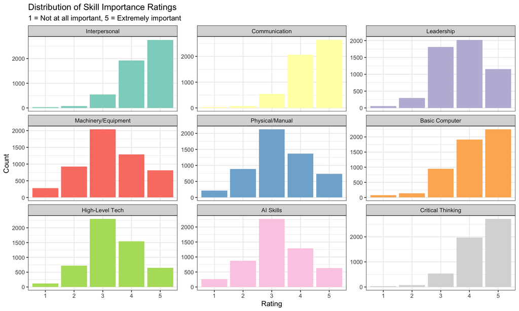

```r
skills_rev %>%
  pivot_longer(everything(), names_to = "Skill", values_to = "Rating") %>%
  mutate(Skill = factor(Skill, levels = skill_labels)) %>%
  ggplot(aes(x = factor(Rating), fill = Skill)) +
  geom_bar(show.legend = FALSE) +
  facet_wrap(~Skill, scales = "free_y", ncol = 3) +
  scale_fill_brewer(palette = "Set3") +
  labs(
    title    = "Distribution of Skill Importance Ratings",
    subtitle = "1 = Not at all important, 5 = Extremely important",
    x = "Rating", y = "Count"
  ) +
  theme_bw(base_size = 10)
```

## 4.2 Mean Importance Ratings

```r
mean_ratings <- skills_rev %>%
  summarise(across(everything(), mean)) %>%
  pivot_longer(everything(), names_to = "Skill", values_to = "Mean") %>%
  arrange(desc(Mean)) %>%
  mutate(Skill = fct_inorder(Skill))

knitr::kable(
  mean_ratings %>% mutate(Mean = round(Mean, 3)),
  caption = "Mean Skill Importance Ratings (5 = Extremely Important)",
  col.names = c("Skill", "Mean Rating")
)
```

Mean Skill Importance Ratings (5 = Extremely Important)

| Skill | Mean Rating |
| --- | --- |
| Interpersonal | 4.369 |
| Critical Thinking | 4.360 |
| Communication | 4.351 |
| Basic Computer | 4.148 |
| Leadership | 3.734 |
| High-Level Tech | 3.352 |
| Physical/Manual | 3.287 |
| Machinery/Equipment | 3.267 |
| AI Skills | 3.215 |

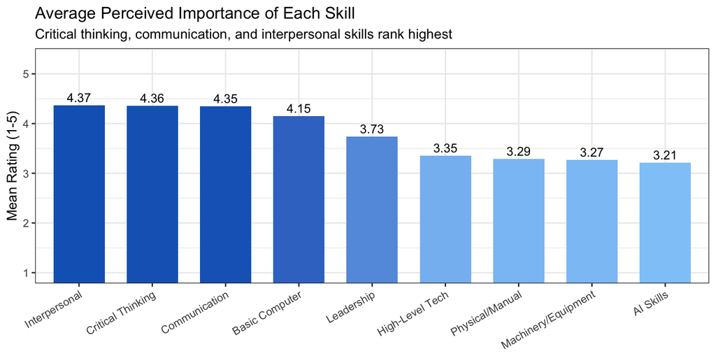

```r
ggplot(mean_ratings, aes(x = Skill, y = Mean, fill = Mean)) +
  geom_col(width = 0.7) +
  geom_text(aes(label = round(Mean, 2)), vjust = -0.4, size = 3.5) +
  scale_fill_gradient(low = "#90CAF9", high = "#1565C0") +
  coord_cartesian(ylim = c(1, 5.3)) +
  labs(
    title    = "Average Perceived Importance of Each Skill",
    subtitle = "Critical thinking, communication, and interpersonal skills rank highest",
    x = NULL, y = "Mean Rating (1-5)"
  ) +
  theme_bw(base_size = 11) +
  theme(
    axis.text.x  = element_text(angle = 30, hjust = 1),
    legend.position = "none"
  )
```

## 4.3 Correlation Matrix

```r
cor_mat <- cor(skills_rev)

cor_mat %>%
  round(2) %>%
  knitr::kable(caption = "Pearson Correlation Matrix of Skill Importance Items")
```

Pearson Correlation Matrix of Skill Importance Items

|  | Interpersonal | Communication | Leadership | Machinery/Equipment | Physical/Manual | Basic Computer | High-Level Tech | AI Skills | Critical Thinking |
| --- | --- | --- | --- | --- | --- | --- | --- | --- | --- |
| Interpersonal | 1.00 | 0.56 | 0.38 | 0.13 | 0.14 | 0.37 | 0.20 | 0.20 | 0.52 |
| Communication | 0.56 | 1.00 | 0.36 | 0.14 | 0.13 | 0.43 | 0.24 | 0.21 | 0.55 |
| Leadership | 0.38 | 0.36 | 1.00 | 0.28 | 0.27 | 0.28 | 0.31 | 0.32 | 0.39 |
| Machinery/Equipment | 0.13 | 0.14 | 0.28 | 1.00 | 0.59 | 0.14 | 0.33 | 0.29 | 0.19 |
| Physical/Manual | 0.14 | 0.13 | 0.27 | 0.59 | 1.00 | 0.04 | 0.23 | 0.21 | 0.15 |
| Basic Computer | 0.37 | 0.43 | 0.28 | 0.14 | 0.04 | 1.00 | 0.33 | 0.29 | 0.42 |
| High-Level Tech | 0.20 | 0.24 | 0.31 | 0.33 | 0.23 | 0.33 | 1.00 | 0.36 | 0.28 |
| AI Skills | 0.20 | 0.21 | 0.32 | 0.29 | 0.21 | 0.29 | 0.36 | 1.00 | 0.23 |
| Critical Thinking | 0.52 | 0.55 | 0.39 | 0.19 | 0.15 | 0.42 | 0.28 | 0.23 | 1.00 |

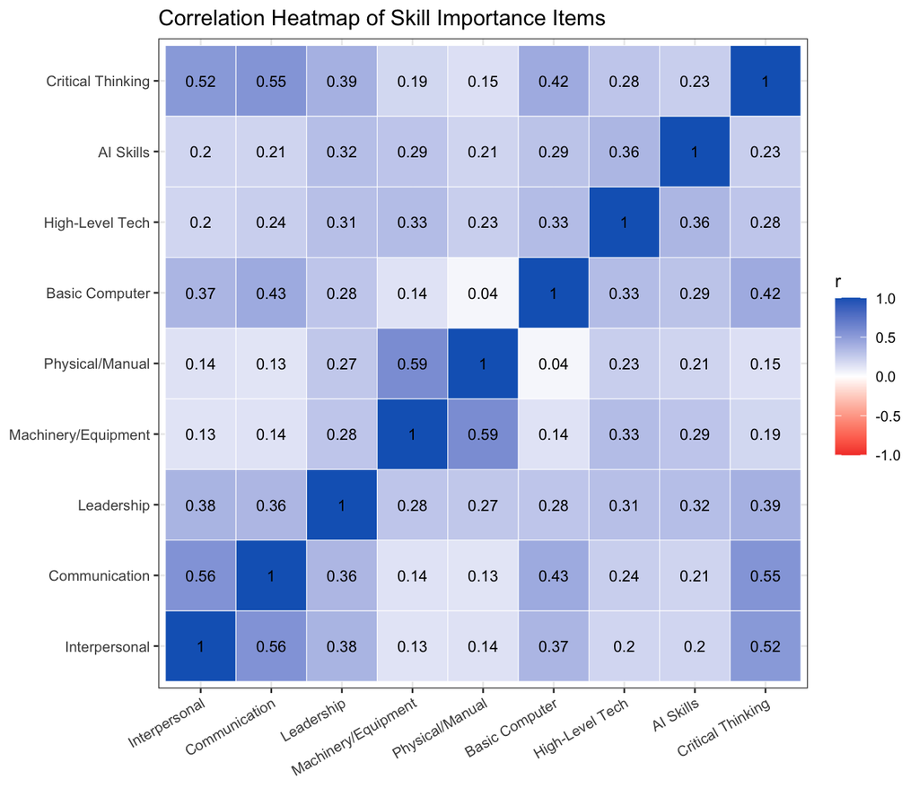

```r
# Visualise as heatmap
cor_mat %>%
  as.data.frame() %>%
  rownames_to_column("Skill1") %>%
  pivot_longer(-Skill1, names_to = "Skill2", values_to = "r") %>%
  mutate(
    Skill1 = factor(Skill1, levels = skill_labels),
    Skill2 = factor(Skill2, levels = skill_labels)
  ) %>%
  ggplot(aes(x = Skill1, y = Skill2, fill = r)) +
  geom_tile(color = "white") +
  geom_text(aes(label = round(r, 2)), size = 3) +
  scale_fill_gradient2(
    low = "#F44336", mid = "white", high = "#1565C0",
    midpoint = 0, limits = c(-1, 1)
  ) +
  labs(
    title = "Correlation Heatmap of Skill Importance Items",
    x = NULL, y = NULL, fill = "r"
  ) +
  theme_bw(base_size = 10) +
  theme(axis.text.x = element_text(angle = 30, hjust = 1))
```

**Finding:** Moderate positive correlations exist among most skill items, suggesting respondents who rate one skill as important tend to rate others highly too. The physical/manual and machinery skills cluster together, while critical thinking, communication, and interpersonal skills form another cluster. This correlation structure justifies PCA.

# 5 Why PCA?

PCA is appropriate here for three reasons:

**1. Multiple correlated variables.** The correlation heatmap shows moderate correlations among skill items. PCA identifies the underlying dimensions driving these correlations.

**2. Dimensionality reduction.** Nine variables measuring related constructs can likely be summarised by fewer components without much information loss.

**3. Latent structure discovery.** Rather than treating each skill independently, PCA reveals whether there are broader dimensions such as “cognitive skills” vs “physical skills” vs “social skills” that better describe how respondents think about workplace competence.

**How PCA works:** PCA finds linear combinations of the original variables (called principal components) that maximise explained variance. The first component captures the most variance, the second captures the most of what remains (orthogonal to the first), and so on. Components are defined by **loadings**: the weights each original variable contributes to each component.

# 6 Data Splitting

We split the data before fitting PCA to ensure the component structure is validated on held-out data.

```r
set.seed(42)
skills_split <- initial_split(skills_rev, prop = 0.80)
skills_train <- training(skills_split)
skills_test  <- testing(skills_split)

cat("Training observations:", nrow(skills_train), "\n")
```

```
## Training observations: 4266
```

```r
cat("Test observations:    ", nrow(skills_test),  "\n")
```

```
## Test observations:     1067
```

# 7 PCA Fitting

We use `tidymodels` `recipe()` with `step_normalize()` (mean-center and scale to unit variance) followed by `step_pca()`. Normalisation is essential before PCA so that variables measured on different scales do not dominate the components simply due to larger variance.

```r
pca_recipe <- recipe(~ ., data = skills_train) %>%
  step_normalize(all_numeric_predictors()) %>%
  step_pca(all_numeric_predictors(), id = "pca")

pca_prep <- prep(pca_recipe)
```

# 8 Determining the Number of Components

## 8.1 Scree Plot

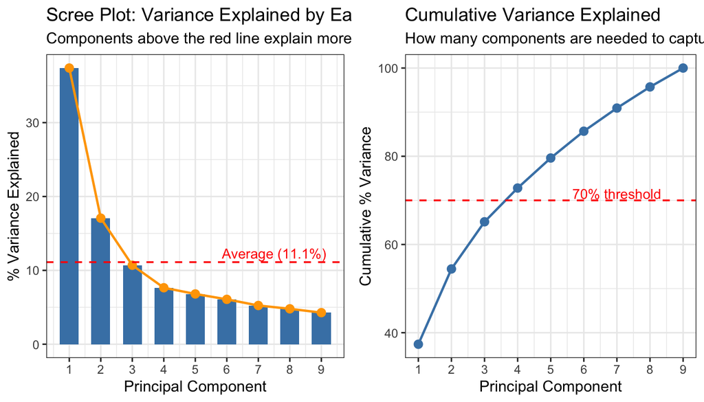

```r
variance_explained <- tidy(pca_prep, id = "pca", type = "variance")

# Percent variance by component
pct_var <- variance_explained %>%
  dplyr::filter(terms == "percent variance") %>%
  dplyr::filter(component <= 9)

cumulative_var <- variance_explained %>%
  dplyr::filter(terms == "cumulative percent variance") %>%
  dplyr::filter(component <= 9)

p_scree <- ggplot(pct_var, aes(x = component, y = value)) +
  geom_col(fill = "steelblue", width = 0.6) +
  geom_line(color = "orange", linewidth = 0.8) +
  geom_point(color = "orange", size = 2.5) +
  geom_hline(yintercept = 100/9, linetype = "dashed",
             color = "red", linewidth = 0.6) +
  annotate("text", x = 7.5, y = 100/9 + 1.2,
           label = "Average (11.1%)", color = "red", size = 3.5) +
  scale_x_continuous(breaks = 1:9) +
  labs(
    title    = "Scree Plot: Variance Explained by Each Component",
    subtitle = "Components above the red line explain more than average",
    x = "Principal Component", y = "% Variance Explained"
  ) +
  theme_bw(base_size = 11)

p_cumulative <- ggplot(cumulative_var, aes(x = component, y = value)) +
  geom_line(color = "steelblue", linewidth = 0.8) +
  geom_point(color = "steelblue", size = 2.5) +
  geom_hline(yintercept = 70, linetype = "dashed",
             color = "red", linewidth = 0.6) +
  annotate("text", x = 7, y = 71.5,
           label = "70% threshold", color = "red", size = 3.5) +
  scale_x_continuous(breaks = 1:9) +
  labs(
    title    = "Cumulative Variance Explained",
    subtitle = "How many components are needed to capture 70% of variance?",
    x = "Principal Component", y = "Cumulative % Variance"
  ) +
  theme_bw(base_size = 11)

grid.arrange(p_scree, p_cumulative, ncol = 2)
```

```r
pct_var %>%
  left_join(cumulative_var, by = "component", suffix = c("_pct", "_cum")) %>%
  dplyr::select(component, value_pct, value_cum) %>%
  mutate(across(where(is.numeric), ~round(., 2))) %>%
  knitr::kable(
    caption = "Variance Explained by Each Principal Component",
    col.names = c("Component", "% Variance Explained", "Cumulative %")
  )
```

Variance Explained by Each Principal Component

| Component | % Variance Explained | Cumulative % |
| --- | --- | --- |
| 1 | 37.39 | 37.39 |
| 2 | 17.07 | 54.45 |
| 3 | 10.69 | 65.15 |
| 4 | 7.65 | 72.80 |
| 5 | 6.81 | 79.61 |
| 6 | 6.08 | 85.68 |
| 7 | 5.24 | 90.93 |
| 8 | 4.80 | 95.72 |
| 9 | 4.28 | 100.00 |

# 9 Component Loadings

Loadings show how strongly each original variable contributes to each principal component. Positive loadings indicate variables that increase together; negative loadings indicate variables that move in the opposite direction.

```r
loadings <- tidy(pca_prep, id = "pca", type = "coef") %>%
  dplyr::filter(component %in% c("PC1", "PC2", "PC3")) %>%
  dplyr::select(terms, component, value) %>%
  pivot_wider(names_from = component, values_from = value) %>%
  mutate(across(where(is.numeric), ~round(., 3))) %>%
  dplyr::rename(Skill = terms)

knitr::kable(
  loadings,
  caption = "PCA Loadings for the First Three Components"
)
```

PCA Loadings for the First Three Components

| Skill | PC1 | PC2 | PC3 |
| --- | --- | --- | --- |
| Interpersonal | -0.366 | -0.300 | -0.320 |
| Communication | -0.382 | -0.313 | -0.207 |
| Leadership | -0.362 | 0.038 | -0.104 |
| Machinery/Equipment | -0.268 | 0.561 | -0.158 |
| Physical/Manual | -0.230 | 0.559 | -0.391 |
| Basic Computer | -0.340 | -0.239 | 0.333 |
| High-Level Tech | -0.318 | 0.187 | 0.498 |
| AI Skills | -0.302 | 0.180 | 0.529 |
| Critical Thinking | -0.396 | -0.245 | -0.166 |

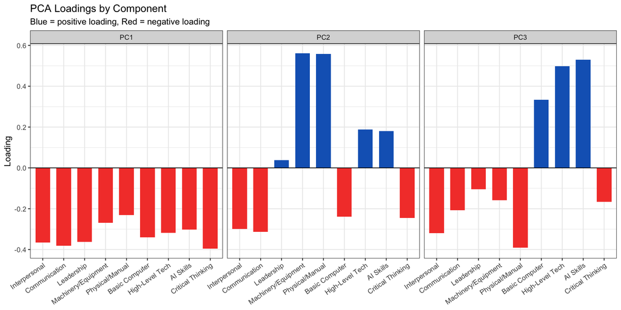

```r
tidy(pca_prep, id = "pca", type = "coef") %>%
  dplyr::filter(component %in% c("PC1", "PC2", "PC3")) %>%
  dplyr::select(terms, component, value) %>%
  mutate(
    terms     = factor(terms, levels = skill_labels),
    component = factor(component, levels = c("PC1", "PC2", "PC3"))
  ) %>%
  ggplot(aes(x = terms, y = value, fill = value > 0)) +
  geom_col(show.legend = FALSE, width = 0.7) +
  geom_hline(yintercept = 0, linewidth = 0.4) +
  scale_fill_manual(values = c("TRUE" = "#1565C0", "FALSE" = "#F44336")) +
  facet_wrap(~component, ncol = 3) +
  labs(
    title = "PCA Loadings by Component",
    subtitle = "Blue = positive loading, Red = negative loading",
    x = NULL, y = "Loading"
  ) +
  theme_bw(base_size = 10) +
  theme(axis.text.x = element_text(angle = 35, hjust = 1))
```

**Interpreting the components:**

- **PC1 (General Skill Skepticism/Endorsement):** All variables load negatively on PC1, which is a sign convention artefact — PCA directions are arbitrary. We flip the sign of PC1 scores below so that high PC1 = high overall skill endorsement. This component captures a respondent’s general tendency to view all skill types as important or unimportant, regardless of skill category.
- **PC2 (Physical vs Cognitive Skills):** Strong positive loadings on physical skills (Machinery/Equipment, Physical/Manual) and strong negative loadings on cognitive skills (Communication, Interpersonal, Critical Thinking). Respondents with high PC2 scores emphasise physical competency; those with low PC2 scores emphasise knowledge work skills.
- **PC3 (Emerging vs Traditional Skills):** Strong positive loadings on AI Skills and High-Level Tech, and negative loadings on Physical/Manual and Interpersonal skills. This component separates respondents who view emerging technology skills as most critical from those who prioritise established interpersonal and physical skills.

# 10 PCA Biplot

The biplot shows both the individual observations (projected onto the first two components) and the original variable vectors (loadings), giving a combined view of the component structure.

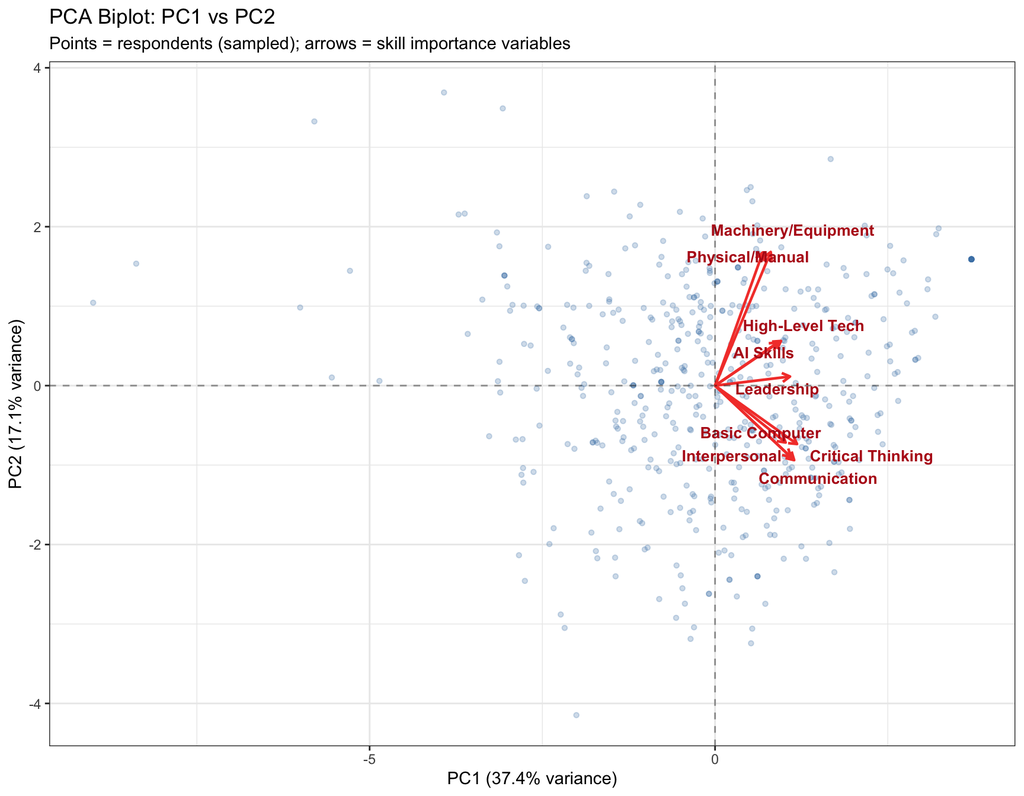

```r
# Project training data onto components
pca_scores <- bake(pca_prep, new_data = skills_train) %>%
  mutate(PC1 = -PC1)  # flip sign so high PC1 = high overall skill endorsement

# Get loadings for arrows — flip PC1 sign to match score direction
arrows_df <- tidy(pca_prep, id = "pca", type = "coef") %>%
  dplyr::filter(component %in% c("PC1", "PC2")) %>%
  dplyr::select(terms, component, value) %>%
  pivot_wider(names_from = component, values_from = value) %>%
  dplyr::rename(Skill = terms) %>%
  mutate(PC1 = -PC1)

# Sample 500 points for clarity
set.seed(42)
pca_sample <- pca_scores %>% dplyr::slice_sample(n = 500)

ggplot() +
  geom_point(
    data = pca_sample,
    aes(x = PC1, y = PC2),
    alpha = 0.25, color = "steelblue", size = 1.2
  ) +
  geom_segment(
    data = arrows_df,
    aes(x = 0, y = 0, xend = PC1 * 3, yend = PC2 * 3),
    arrow = arrow(length = unit(0.2, "cm")),
    color = "#F44336", linewidth = 0.8
  ) +
  geom_text_repel(
    data = arrows_df,
    aes(x = PC1 * 3.2, y = PC2 * 3.2, label = Skill),
    color = "#B71C1C", size = 3.5, fontface = "bold",
    max.overlaps = 15
  ) +
  geom_hline(yintercept = 0, linetype = "dashed", alpha = 0.4) +
  geom_vline(xintercept = 0, linetype = "dashed", alpha = 0.4) +
  labs(
    title    = "PCA Biplot: PC1 vs PC2",
    subtitle = "Points = respondents (sampled); arrows = skill importance variables",
    x = paste0("PC1 (", round(pct_var$value[1], 1), "% variance)"),
    y = paste0("PC2 (", round(pct_var$value[2], 1), "% variance)")
  ) +
  theme_bw(base_size = 11)
```

**Reading the biplot:**

- **Arrow direction** shows which component each variable loads onto most strongly.
- **Arrow length** reflects the variable’s contribution (longer = more influential).
- **Arrow angle** between two variables indicates their correlation (small angle = high positive correlation; opposite directions = negative correlation).
- Physical/Manual and Machinery arrows point in the opposite direction to Communication and Critical Thinking on PC2, confirming the cognitive-vs-physical dimension.

# 11 Validation on Test Set

We apply the same PCA transformation (fitted on training data) to the held-out test set to ensure the component structure generalises.

```r
# Project test data using training-fitted PCA, flip PC1 to match training
pca_test <- bake(pca_prep, new_data = skills_test) %>%
  mutate(PC1 = -PC1)

# Compare variance of PC scores across train and test
train_var <- pca_scores %>%
  dplyr::select(PC1, PC2, PC3) %>%
  summarise(across(everything(), var)) %>%
  pivot_longer(everything(), names_to = "Component", values_to = "Train_Var")

test_var <- pca_test %>%
  dplyr::select(PC1, PC2, PC3) %>%
  summarise(across(everything(), var)) %>%
  pivot_longer(everything(), names_to = "Component", values_to = "Test_Var")

train_var %>%
  left_join(test_var, by = "Component") %>%
  mutate(across(where(is.numeric), ~round(., 4))) %>%
  knitr::kable(
    caption = "PC Score Variance: Training vs Test Set",
    col.names = c("Component", "Train Variance", "Test Variance")
  )
```

PC Score Variance: Training vs Test Set

| Component | Train Variance | Test Variance |
| --- | --- | --- |
| PC1 | 3.3649 | 3.3618 |
| PC2 | 1.5361 | 1.4759 |
| PC3 | 0.9625 | 0.9262 |

> **Validation check:** Similar variance in PC scores across train and test sets indicates that the component structure identified on the training data generalises well to unseen respondents.

## 11.1 Score Distributions (Test Set)

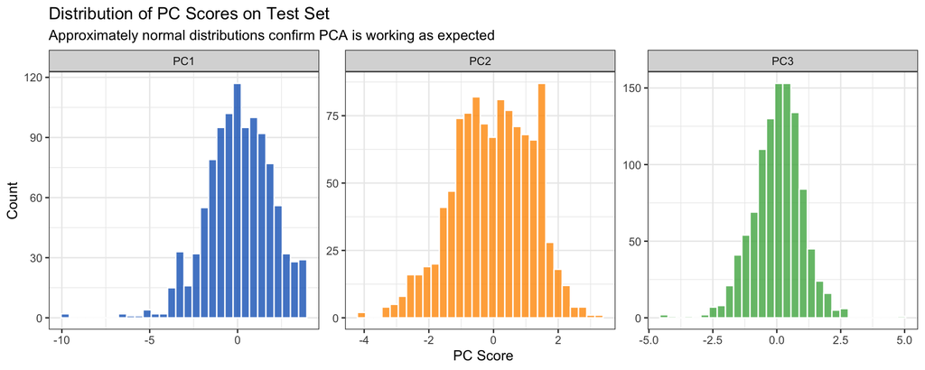

```r
pca_test %>%
  dplyr::select(PC1, PC2, PC3) %>%
  pivot_longer(everything(), names_to = "Component", values_to = "Score") %>%
  ggplot(aes(x = Score, fill = Component)) +
  geom_histogram(bins = 30, color = "white", alpha = 0.8, show.legend = FALSE) +
  facet_wrap(~Component, scales = "free") +
  scale_fill_manual(values = c(PC1 = "#1565C0", PC2 = "#FF9800", PC3 = "#4CAF50")) +
  labs(
    title    = "Distribution of PC Scores on Test Set",
    subtitle = "Approximately normal distributions confirm PCA is working as expected",
    x = "PC Score", y = "Count"
  ) +
  theme_bw(base_size = 11)
```

# 12 Using PCA Scores for Downstream Analysis

One practical use of PCA is to use the component scores as predictors in a regression model. Here we demonstrate a simple linear regression predicting overall job satisfaction (`JOBSAT_W157`) from the three PCA components.

```r
# Merge PC scores back with outcome variable
jobsat <- atp %>%
  dplyr::select(RESPID, JOBSAT_W157) %>%
  dplyr::filter(!JOBSAT_W157 %in% c(98, 99)) %>%
  drop_na()

# Add row index to skills_train for merging
train_with_id <- skills_train %>%
  bind_cols(
    atp %>%
      dplyr::select(RESPID, JOBSAT_W157) %>%
      dplyr::filter(!JOBSAT_W157 %in% c(98, 99)) %>%
      drop_na() %>%
      dplyr::slice(1:nrow(skills_train))
  )

pca_scores_outcome <- pca_scores %>%
  dplyr::select(PC1, PC2, PC3) %>%   # PC1 already flipped above
  bind_cols(
    train_with_id %>% dplyr::select(JOBSAT_W157)
  ) %>%
  dplyr::filter(!is.na(JOBSAT_W157))

lm_spec <- linear_reg() %>%
  set_engine("lm") %>%
  set_mode("regression")

pca_lm <- lm_spec %>%
  fit(JOBSAT_W157 ~ PC1 + PC2 + PC3, data = pca_scores_outcome)

tidy(pca_lm) %>%
  mutate_if(is.numeric, ~round(., 4)) %>%
  knitr::kable(
    caption = "Regression of Job Satisfaction on PCA Components",
    col.names = c("Term", "Estimate", "Std. Error", "t Statistic", "p-value")
  )
```

Regression of Job Satisfaction on PCA Components

| Term | Estimate | Std. Error | t Statistic | p-value |
| --- | --- | --- | --- | --- |
| (Intercept) | 2.4562 | 0.0143 | 172.2651 | 0.0000 |
| PC1 | 0.0199 | 0.0078 | 2.5631 | 0.0104 |
| PC2 | 0.0077 | 0.0115 | 0.6700 | 0.5029 |
| PC3 | -0.0023 | 0.0145 | -0.1569 | 0.8753 |

```r
glance(pca_lm) %>%
  dplyr::select(r.squared, adj.r.squared, sigma, p.value) %>%
  mutate_if(is.numeric, ~round(., 4)) %>%
  knitr::kable(caption = "Model Fit Statistics")
```

Model Fit Statistics

| r.squared | adj.r.squared | sigma | p.value |
| --- | --- | --- | --- |
| 0.0016 | 9e-04 | 0.9313 | 0.0707 |

> This downstream regression illustrates how PCA components can serve as compact, uncorrelated predictors in further analyses. Note that job satisfaction is a workplace outcome variable rather than a skill perception variable, so the predictive relationship is exploratory rather than confirmatory.

# 13 Summary

## 13.1 PCA Results

PCA: Summary Statistics

[output not shown]